# CptS-483-06

Yang, Liang-liang & Lin, Peng

December 4, 2015

# **Introduction & Background**

Time series analysis is a major branch in statistics that mainly focuses on analyzing data set to study the characteristics of the data and extract meaningful statistics in order to predict future values of the series.

In this project, we have applied two different ways to explore the stock price modeling and prediction. First we will go through several traditional time series modeling and prediction methods and apply them to the stock price analysis. Further, instead of using the statistical modeling methods, we will apply the machine learning technique and do the modeling and prediction based on the historical stock data. After comparison, we will show that the machine learning method is also a powerful tool for financial system analysis.

# **Time Series Based Modeling & Prediction**

## **Data Collection and Cleaning**

The data is downloaded from *Yahoo Finance*, you can easily change the data range of stock price and you can set the data to be daily, weekly and monthly. For the purpose of our project, we use the monthly data. For different usage, We download several files with different time range or different stocks.

```r
AAPL_monthly_full_data <- read.csv(file = "AAPL_monthly_full_table.csv") # data from (1990,01) to (2015,12)
INTC_monthly_full_data <- read.csv(file = "INTC_monthly_full_table.csv") # same as above
MSFT_monthly_full_data <- read.csv(file = "MSFT_monthly_full_table.csv") # same as above
AAPL_monthly_last_five_data <- read.csv(file = "AAPL_monthly_last_five_table.csv") #data from (2010,01) to (2014,12)
AAPL_monthly_last_six_data <- read.csv(file = "AAPL_monthly_last_six_table.csv") #data from (2010,01) to (2015,12)
```

Here a little explain of the data. We will use the first three data sets for visulation and comparison (data from (1990,01) to (2015,12)), the the data (2010,01 to 2014,12) for modeling and last 12 months for prediction. And you can see a summary of the data

```r
summary(AAPL_monthly_full_data)
```

```
##          Date          Open             High             Low
##  1990-01-02:  1   Min.   : 13.62   Min.   : 14.95   Min.   : 12.72
##  1990-02-01:  1   1st Qu.: 28.44   1st Qu.: 32.44   1st Qu.: 25.62
##  1990-03-01:  1   Median : 51.69   Median : 57.99   Median : 46.50
##  1990-04-02:  1   Mean   :123.15   Mean   :132.94   Mean   :112.49
##  1990-05-01:  1   3rd Qu.:126.30   3rd Qu.:136.07   3rd Qu.:116.56
##  1990-06-01:  1   Max.   :671.16   Max.   :705.07   Max.   :656.00
##  (Other)   :306
##      Close            Volume            Adj.Close
##  Min.   : 13.12   Min.   : 29405200   Min.   :  0.4365
##  1st Qu.: 28.53   1st Qu.: 59189975   1st Qu.:  1.2321
##  Median : 52.45   Median : 95546700   Median :  1.9130
##  Mean   :123.00   Mean   :115797759   Mean   : 20.4386
##  3rd Qu.:125.53   3rd Qu.:150102125   3rd Qu.: 24.7593
##  Max.   :667.10   Max.   :468331100   Max.   :129.1402
##
```

As you can see, there are several columns, and for our purpose we will use the time and Adj.Close columns. First let us just make a simple plot for AAPL Adj.Close price

## **Time Series Visualization and Description**

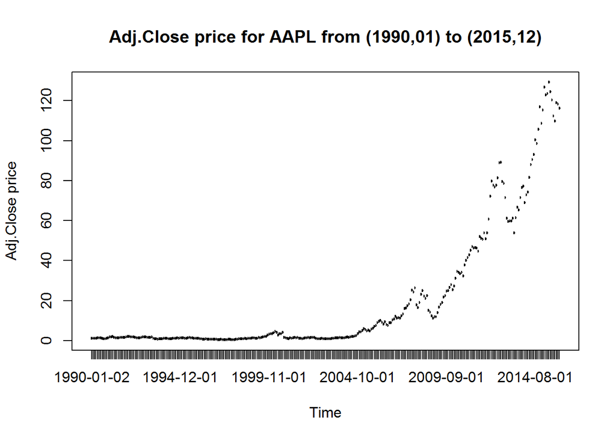

```r
plot(AAPL_monthly_full_data$Adj.Close~AAPL_monthly_full_data$Date, main="Adj.Close price for AAPL from (1990,01) to (2015,12)", xlab="Time", ylab="Adj.Close price", xlab="Time", col="blue")
```

One problem for the original data is that the raw data is ordered from newest to oldest. As We will use the **ts()** function below, the data should be modified as from oldest to newest. Below is an example, we use the for loop to change the order od the Adj.Close price:

```r
for(i in 1:156){
  temp = AAPL_monthly_full_data$Adj.Close[i]
  AAPL_monthly_full_data$Adj.Close[i] = AAPL_monthly_full_data$Adj.Close[313-i]
  AAPL_monthly_full_data$Adj.Close[313-i] = temp
}
```

In R, time series objects usually use a class **ts()**, which includes several functions like start, end and frequency (the frequency is the number of observations per unit of time), an example is given like below:

```r
AAPL_monthly_full_data.ts = ts(as.numeric(AAPL_monthly_full_data$Adj.Close), start=c(1990,1), end=c(2015,12),  freq=12)
```

[output not shown]

Also you can easily plot the stock price use the ts() function, the result is exactly the same as above

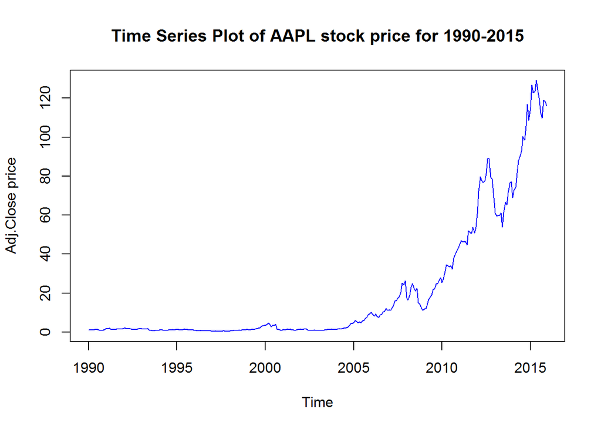

```r
plot(AAPL_monthly_full_data.ts, ylab='Adj.Close price',xlab="Time", main="Time Series Plot of AAPL stock price for 1990-2015", col="blue")
```

There are a number of features in the above time series plot. For example, it is apparent that there is increase trend for the Adj.Close price of AAPL with time. Another feature. Besides, clearly there two regions that Apple’s stock price decreased a lot, one is on **2008**, another is from **2012** autumn to **2013** spring. As we all know, the first collapse is due to the global financial crisis of 2008. The second collapse may have many reasons. From 2010 to 2012, the Apple’s stock price increased too fast (I think partially due to the hot sales of iphone4 and 4s). In 2012 autumn, the iphone 5 comes out but it doesn’t sell good as predict. Beside, inorder to compete with other companys like Samsung, Apple also need to increase the cost, so it had fallen by 40% over that six months.

In addition to the increase trend and two apparant collapse, there might also be some seasonal effect on the stock price. In time series analysis, there is usually a repeating pattern with each year, which is known as seasonal variation. We will also claim the seasonal effect on the below modeling and prediction parts.

To get a clearer view of the trend, the seasonal effect can be removed by aggregating the data to the annual level, which can be achieved in **R** using the **aggregate** function. A summary of the values for each season can be viewed using a boxplot, with the **cycle** function being used to extract the seasons for each item of data.

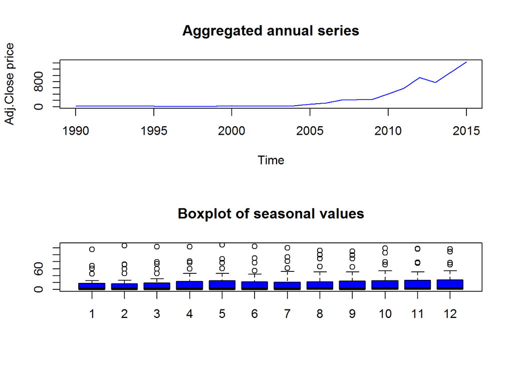

```r
par(mfrow=c(2,1))
plot(aggregate(AAPL_monthly_full_data.ts), main="Aggregated annual series", ylab="Adj.Close price", xlab="Time", col="blue")
boxplot(AAPL_monthly_full_data.ts ~ cycle(AAPL_monthly_full_data.ts), main="Boxplot of seasonal values", col="blue")
```

```r
par(mfrow=c(1,1))
```

You can see an increasing trend in the aggregating plot.

As the change in the stock price is not very big before 2010, and in order to make out model more simple (shorter data range), in the modeling and prediction part, we will focus on the time start from 2010. We can make the time series plot from (2010,01) to (2014,12):

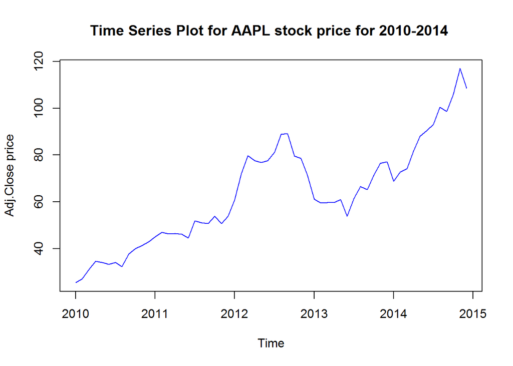

```r
plot(AAPL_monthly_last_five_data.ts, ylab='Adj.Close price', main="Time Series Plot for AAPL stock price for 2010-2014 ", col="blue")
```

Two local trends are emphasised when the series is partitioned into two subseries based on the perieds (2010,01) to (2012,08) and (2012,09) to (2014,12). We can use the **window()** function in R, which is used to extract the subseries.

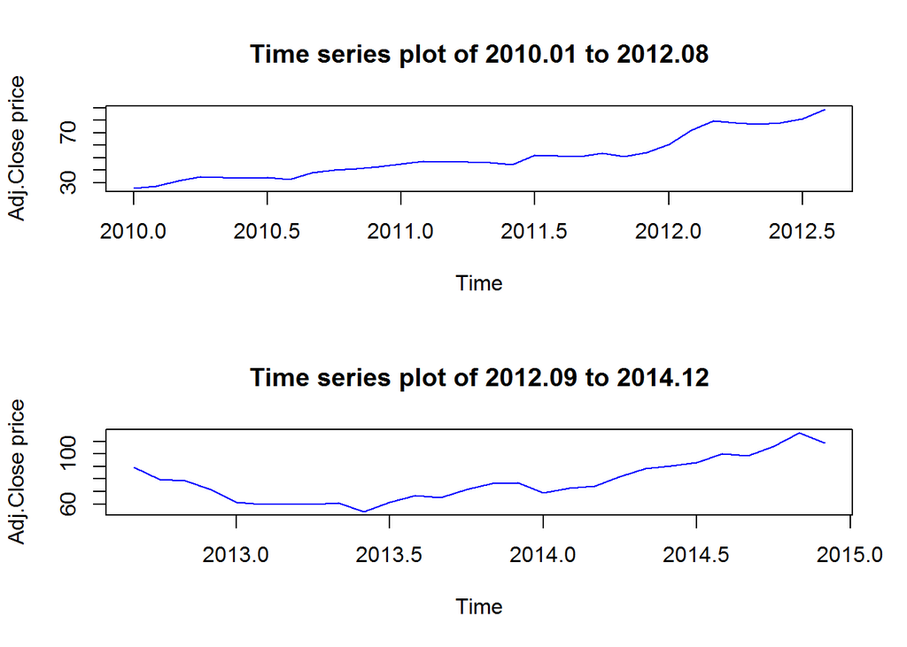

```r
AAPL_monthly_last_five_data.10.12 <- window(AAPL_monthly_last_five_data.ts, start = c(2010,01), end = c(2012,08))
AAPL_monthly_last_five_data.12.14 <- window(AAPL_monthly_last_five_data.ts, start = c(2012,09), end = c(2014,12))
par(mfrow=c(2,1))
plot(AAPL_monthly_last_five_data.10.12, ylab="Adj.Close price", xlab="Time", main="Time series plot of 2010.01 to 2012.08", col="blue")
plot(AAPL_monthly_last_five_data.12.14, ylab="Adj.Close price", xlab="Time", main="Time series plot of 2012.09 to 2014.12", col="blue")
```

```r
par(mfrow=c(1,1))
```

In addition to single time series plot, we can also do multiple time series plots. First let us try to plot three different stocks *“AAPL”*, *“INTC”* and *“MSFT”* by using different frames.

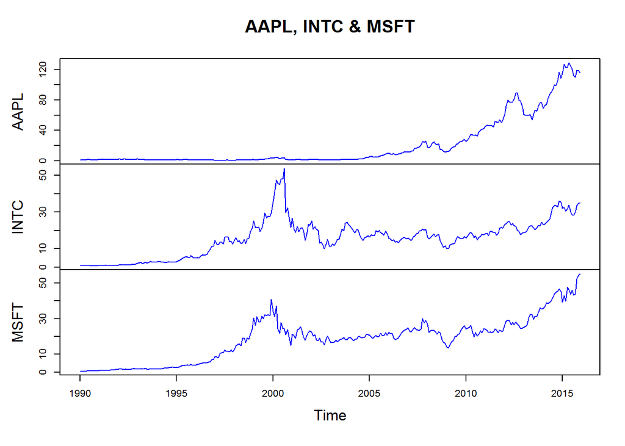

```r
data <- cbind(AAPL_monthly_full_data$Adj.Close, INTC_monthly_full_data$Adj.Close, MSFT_monthly_full_data$Adj.Close)
colnames(data) <- c("AAPL","INTC","MSFT")
data.ts <- ts(data, start=c(1990,1), end=c(2015,12), freq=12)
plot(data.ts, main = "AAPL, INTC & MSFT", col="blue")
```

However, sometimes it can be more instructive to have them in the same frame.

```r
clr <- c("green3","red3","blue3")
plot(data.ts, plot.type="single", ylab="Adj.Close price", col=clr)
ltxt <-colnames(data)
ltxt
```

```
## [1] "AAPL" "INTC" "MSFT"
```

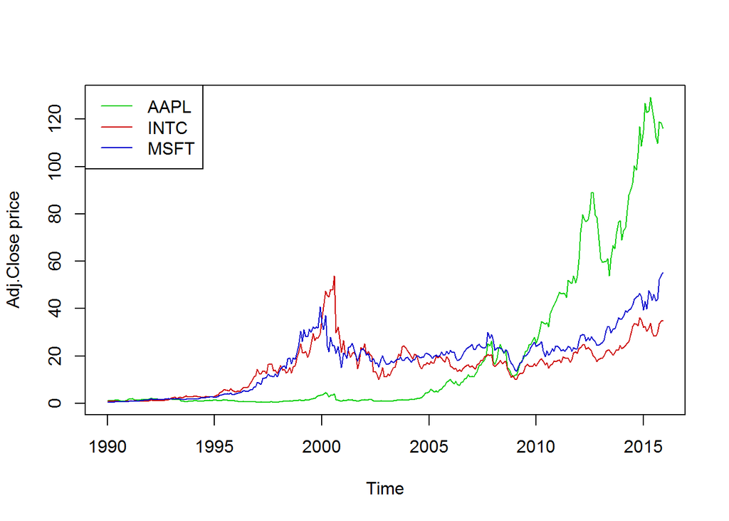

```r
legend("topleft", lty=1, col=clr, legend=ltxt) # add legend
```

From the plot, we can see that the *AAPL* stock price increases munch faster than the other two stocks in the recent five to six years. Besides we can see there is clear peak for *INTC* and *MSFT* at the begining of the 21th century, which we think is due to the revolution of new science and technology then. Also we can see that all three stocks have some decrease during 2008 due to the global financial crisis.

## **Time Series Modeling**

### **Decomposition model**

So far, our analysis has been restricted to plotting the data and looking for features such as trend and seasonal variation Now we want to consider some approaches for modeling time series. The first is based on an assumption that there is a fixed seasonal pattern about a trend.We can estimate the trend by local averaging of the deseasonalised data, and this is implemented by the R function **decompose()**.

Many series are dominated by a trend and/or seasonal effects, so the models in this section are based on these components. A simple additive decomposition model is given by:

$x[t]= m[t] + s[t] + R[t]$

where x[t] is the time series process at time t, m[t] is the trend, s[t] is the seasonal effect, and R[t] is the error term which is a sequence of usually correlated random variables with mean zero. The goal is to find a decomposition such that R[t] is a stationary time series.

If the seasonal effect tends to increase as the trend increases, a multiplicative model may be more appropriate:

$x[t]= m[t].s[t] + R[t]$

Empirical experience says that taking logarithms is beneficial for such data. Also, some basic math shows that this brings us back to the additive case:

$log(x[t])= m'[t] + s'[t] + R'[t]$

First let us try the additive model:

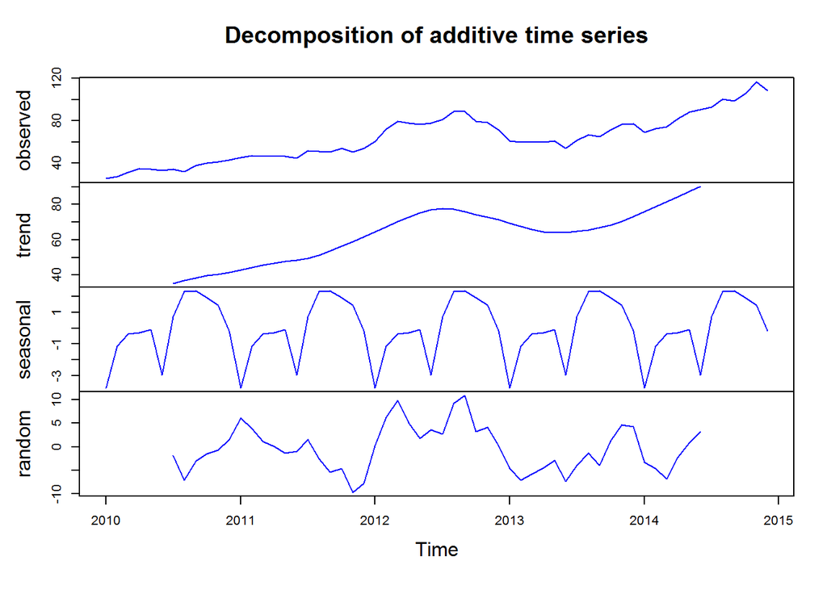

```r
AAPL_monthly_last_five_data.decom_add <- decompose(AAPL_monthly_last_five_data.ts, type="additive")
plot(AAPL_monthly_last_five_data.decom_add, col="blue")
```

Then let us try the multiplicative model, and its corresponding logarithms:

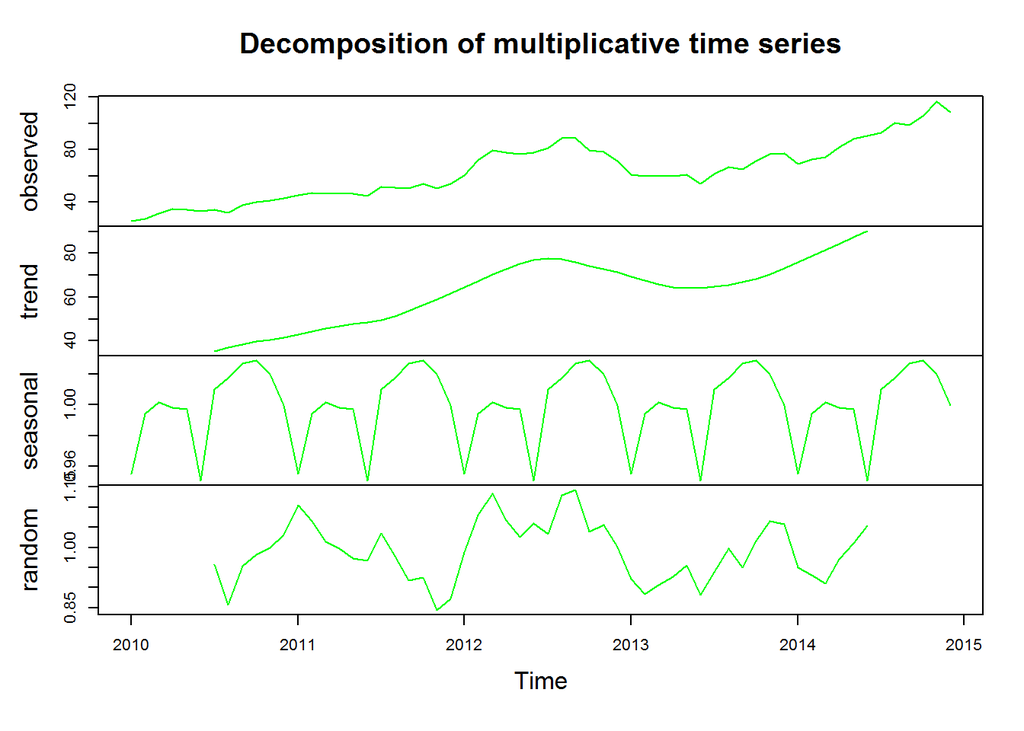

```r
AAPL_monthly_last_five_data.decom_mult <- decompose(AAPL_monthly_last_five_data.ts, type = "mult")
plot(AAPL_monthly_last_five_data.decom_mult, col="green")
```

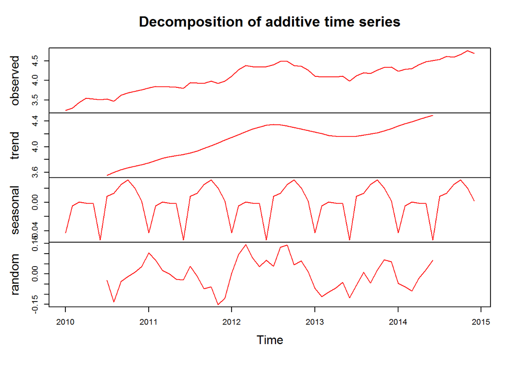

```r
AAPL_monthly_last_five_data.decom_log <- decompose(AAPL_monthly_last_five_data.log.ts, type="additive")
plot(AAPL_monthly_last_five_data.decom_log, col='red')
```

Note that the last additive model is based on the logarithmic transformation of multiplicative model.

We can compare the additive model and multiplicative model. In this example, the multiplicative model would seem more appropriate than the additive model because the variance of the original series and trend increase with time (see the random component we can find that the multi model has smaller value).

We can also put the decomposition parts together and compare them to the real observed data. Below we use multiplicative model as an example:

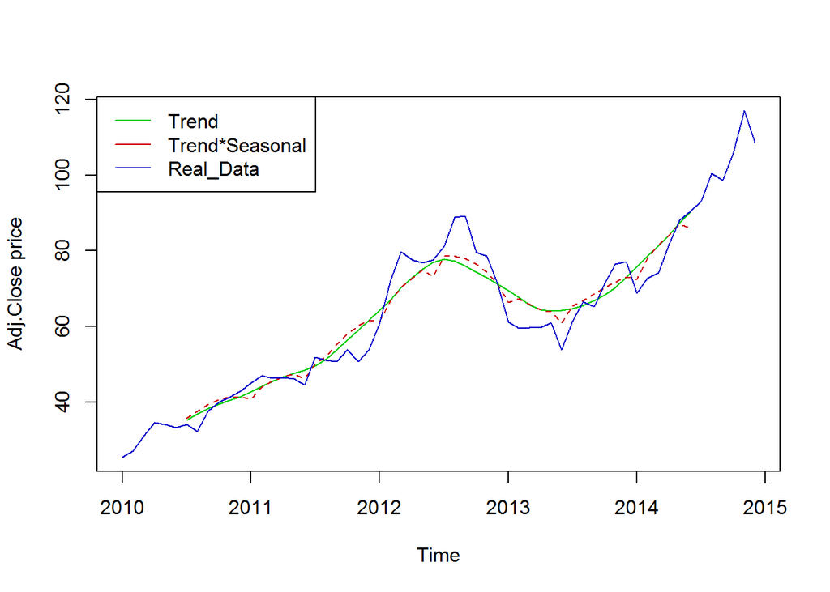

```r
clr <- c("green3","red3","blue3")
Real_Data <- AAPL_monthly_last_five_data$Adj.Close
Trend <- AAPL_monthly_last_five_data.decom_mult$trend
Seasonal <- AAPL_monthly_last_five_data.decom_mult$seasonal
Mult_cbind <- cbind(Trend, Trend * Seasonal, Real_Data)
colnames(Mult_cbind) <- c("Trend","Trend*Seasonal","Real_Data")
ts.plot(Mult_cbind, lty = 1:2, col=clr, ylab="Adj.Close price")
legend("topleft", lty=1, col=clr, legend=colnames(Mult_cbind))
```

Once we have identified any trend and seasonal effects, we can get the random component. But the random component is not necessarily well modelled by independent random variables. In many cases, consecutive variables will be correlated. If we identify such correlations, we can improve our forecasts.

Consider a time series model that is stationary in the mean and the variance. The variables may be correlated, and the model is second-order stationary if the correlation between variables depends only on the number of time steps separating them. The number of time steps between the variables is known as the lag. A correlation of a variable with itself at different times is known as autocorrelation or serial correlation.

In **R**, an autocovariance function (**acvf**), $\gamma$[k], as a function of the lag k is defined as:

$\gamma[k] = E[(x[t] - \mu)(x[t+k] - \mu)]$

And The lag k autocorrelation function (**acf**), $\rho$[k], is defined by: $\rho[k]=\gamma[k]/(\sigma^2)$

By default, the acf function produces a plot of sample acf r[k] against k, which is called the correlogram.

The main use of the correlogram is to detect autocorrelations in the time series after we have removed an estimate of the trend and seasonal variation.

We can apply the **acf()** function to the above three decomposition models (including the logarithmic transformation of multiplicative model):

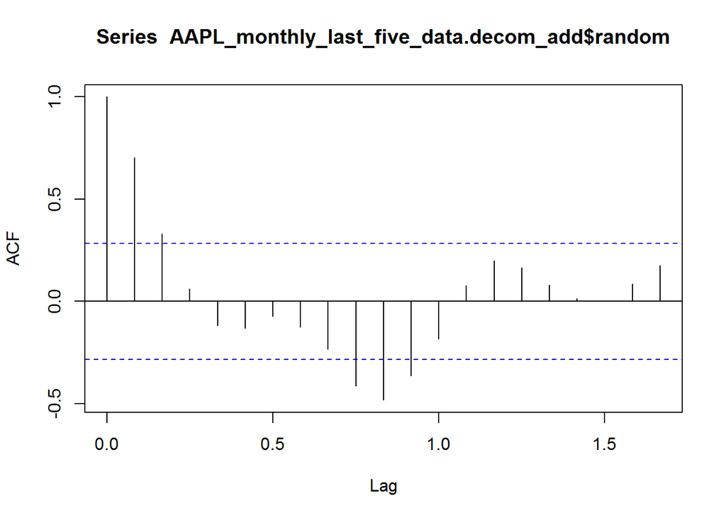

```r
acf(AAPL_monthly_last_five_data.decom_add$random,na.action=na.omit, lag.max = 20) # correlogram for additive model
```

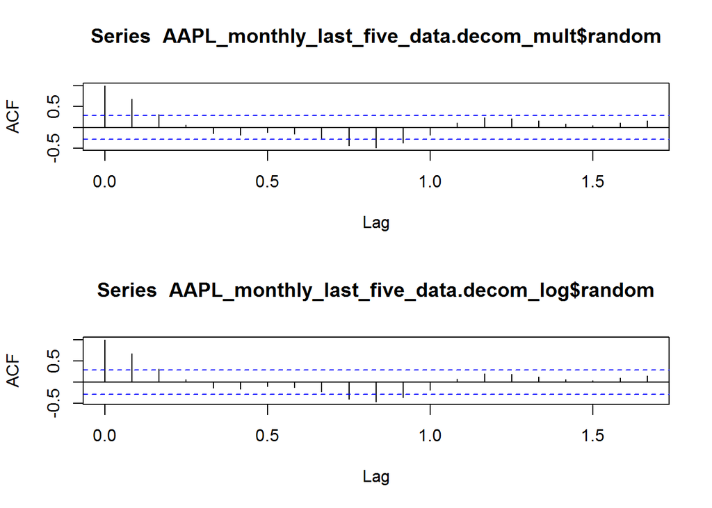

```r
par(mfrow=c(2,1))
acf(AAPL_monthly_last_five_data.decom_mult$random,na.action=na.omit, lag.max = 20) # correlogram for mult model
acf(AAPL_monthly_last_five_data.decom_log$random,na.action=na.omit, lag.max = 20) # correlogram for log model
```

```r
par(mfrow=c(1,1))
```

From the plots we can see the logarithmic transformation of multiplicative model is slightly better than the other two models, but none of all three models performs very well ( there is significant autocorrelation at some lags), hence we may need further modeling.

Also we can plot the correlogram of the original data. the autocorrelations, which are large and positive due to similar values in the series occurring close together in time.

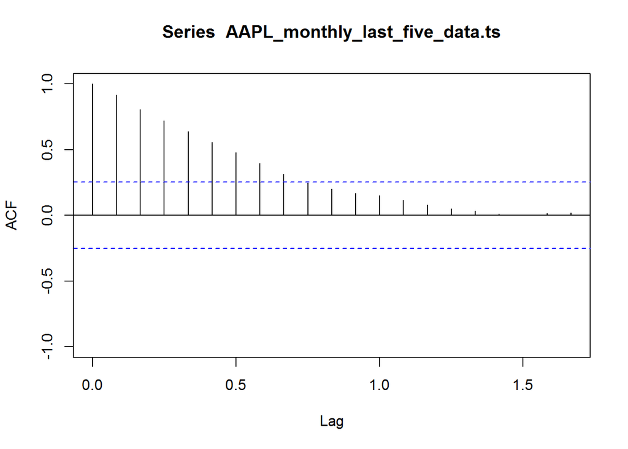

```r
acf(AAPL_monthly_last_five_data.ts, na.action=na.pass, ylim=c(-1,1), lag.max = 20) # just show the correlogram of the the original data
```

### **Linear Regression model**

Trends in time series can be classified as stochastic or deterministic. when we have some plausible physical explanation for a trend we will usually wish to model it in some deterministic manner. Deterministic trends and seasonal variation can be modelled using regression. Time series regression usually differs from a standard regression analysis because the residuals form a time series and therefore tend to be serially correlated.

First let us introduce the linear regression models.

A model for a time series {x[t] : t = 1, . . . n} is linear if it can be expressed as

$x[t] = \alpha0 + \alpha1.u[1,t] + \alpha2.u[2,t] + . . . + \alpha m.u[m,t] + z[t]$

where $u[i,t]$ is the value of the ith predictor (or explanatory) variable at time $t (i = 1, . . . ,m; t = 1, . . . , n)$, $z[t]$ is the error at time t, and $\alpha0$, $\alpha1$, . . . , $\alpha m$ are model parameters.

First we can fit a simple linear regression model for the AAPL stock price from (2010,01) to (2014,12)

```r
AAPL_monthly_last_five_data.ts.lm = lm(AAPL_monthly_last_five_data.ts ~ time(AAPL_monthly_last_five_data.ts))
coef(AAPL_monthly_last_five_data.ts.lm)
```

```
##                          (Intercept) time(AAPL_monthly_last_five_data.ts)
##                         -26665.22705                             13.28163
```

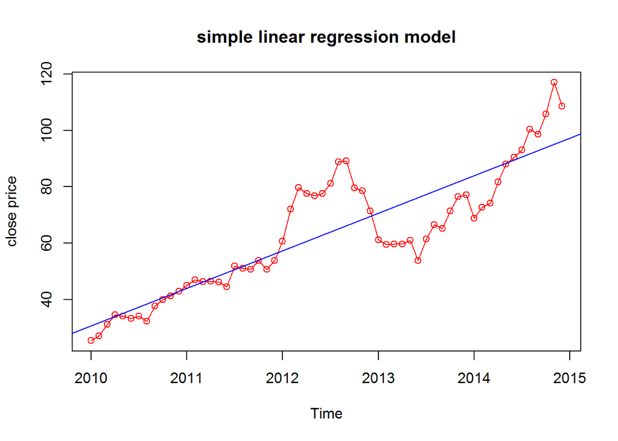

```r
plot(AAPL_monthly_last_five_data.ts, type="o", ylab="close price",col="red", xlab="Time", main="simple linear regression model")
abline(AAPL_monthly_last_five_data.ts.lm, col="blue")
```

After fitting a regression model, we should consider various diagnostic plots. In the case of time series regression, an important diagnostic plot is the correlogram of the residuals:

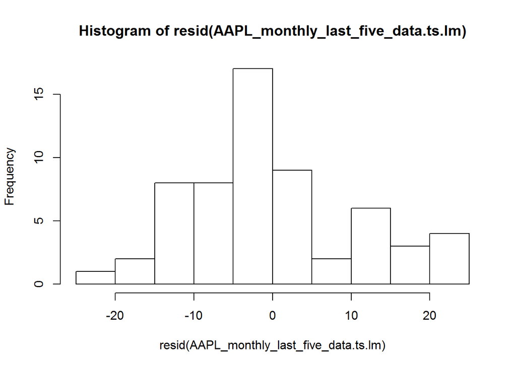

```r
hist(resid(AAPL_monthly_last_five_data.ts.lm)) #should be normal for a good fit
```

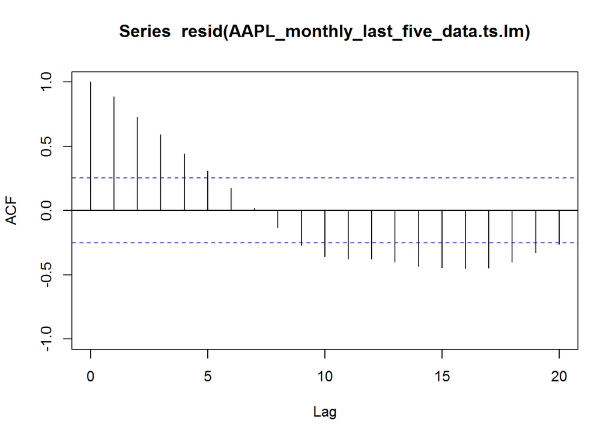

```r
acf(resid(AAPL_monthly_last_five_data.ts.lm), na.action=na.pass, ylim=c(-1,1),lag.max = 20)
```

```r
AIC(AAPL_monthly_last_five_data.ts.lm)
```

```
## [1] 458.6778
```

From the acf() plot, it shows that the simple linear regression model is not very good as the correlogram has some significant autocorrelated points.

As time series are observations measured sequentially in time, seasonal effects are often present in the data, especially annual cycles caused directly or indirectly by the Earth’s movement around the Sun. Since this reason, we should conside the linear model with seasonal variables

A seasonal indicator model for a time series ${x[t] : t = 1, . . . , n}$ containing s seasons and a trend $m[t]$ is given by

$x[t]= m[t] + s[t] + R[t]$

We have already seen this model in the additive decomposition model. Below we can apply the linear model with seasonal variables to our data:

```r
Seas = cycle(AAPL_monthly_last_five_data.ts)
# This gives the positions in the cycle of each obsv.
Time = time(AAPL_monthly_last_five_data.ts)
# This creates the vector of times at which AAPL_monthly_last_five_data.ts was sampled
AAPL_monthly_last_five_data.ts.sv.lm = lm(AAPL_monthly_last_five_data.ts~0+Time+factor(Seas))
# This fit AAPL_monthly_last_five_data.ts to the linear model with seasonal variables
```

Note a zero is used within the formula to ensure that the model does not have an intercept. Now we can take a look at the AAPL_monthly_last_five_data.ts.sv.lm:

```r
summary(AAPL_monthly_last_five_data.ts.sv.lm)
```

```
##
## Call:
## lm(formula = AAPL_monthly_last_five_data.ts ~ 0 + Time + factor(Seas))
##
## Residuals:
##     Min      1Q  Median      3Q     Max
## -19.115  -7.125  -1.593   5.729  21.471
##
## Coefficients:
##                  Estimate Std. Error t value Pr(>|t|)
## Time               12.954      1.049   12.35 2.32e-16 ***
## factor(Seas)1  -26010.853   2110.511  -12.32 2.49e-16 ***
## factor(Seas)2  -26008.459   2110.598  -12.32 2.50e-16 ***
## factor(Seas)3  -26007.011   2110.686  -12.32 2.51e-16 ***
## factor(Seas)4  -26006.288   2110.773  -12.32 2.52e-16 ***
## factor(Seas)5  -26006.153   2110.861  -12.32 2.52e-16 ***
## factor(Seas)6  -26008.490   2110.948  -12.32 2.52e-16 ***
## factor(Seas)7  -26005.205   2111.035  -12.32 2.53e-16 ***
## factor(Seas)8  -26002.813   2111.123  -12.32 2.54e-16 ***
## factor(Seas)9  -26003.483   2111.210  -12.32 2.55e-16 ***
## factor(Seas)10 -26002.722   2111.298  -12.32 2.55e-16 ***
## factor(Seas)11 -26001.085   2111.385  -12.31 2.56e-16 ***
## factor(Seas)12 -26004.225   2111.472  -12.32 2.55e-16 ***
## ---
## Signif. codes:  0 '***' 0.001 '**' 0.01 '*' 0.05 '.' 0.1 ' ' 1
##
## Residual standard error: 11.49 on 47 degrees of freedom
## Multiple R-squared:  0.9771, Adjusted R-squared:  0.9707
## F-statistic: 154.1 on 13 and 47 DF,  p-value: < 2.2e-16
```

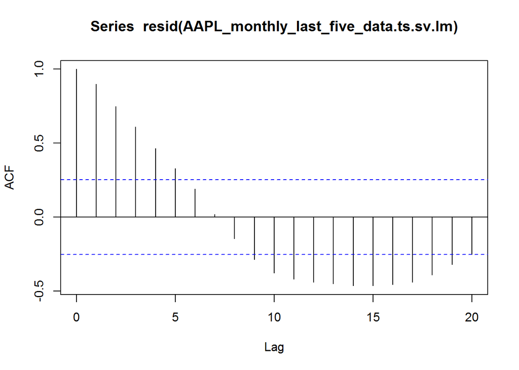

```r
acf(resid(AAPL_monthly_last_five_data.ts.sv.lm),lag.max=20)
```

We can see the results of fitted model, residuals from fitting and coefficients from the summary results. Note that the correlogram plot also shows it is not a good model.

### **Random Walk model**

So far, we have considered two approaches for modelling time series. The first is based on an assumption that there is a fixed seasonal pattern about a trend, and we use the decomposition model. Besides, we also do some regression to fit the time series model. When we fit mathematical models to time series data, we refer to the discrepancies between the fitted values, calculated from the model, and the data as a residual error series.

Since we judge a model to be a good fit if its residual error series appears to be a realisation of independent random variables, it seems natural to build models up from a model of independent random variation, known as discrete white noise.

Before we start the modeling, let us introduce what is white noise. A time series {w[t] : t = 1, 2, . . . , n} is discrete white noise (DWN) if the variables w1,w2, . . .,wn are independent and identically distributed with a mean of zero. This implies that the variables all have the same variance $\sigma^2$ and $Cor(w[i],w[j]) = 0$ for all $i != j$.

After knowing the white noise, we can introduce the random walk model.

Let us first introduce the random wlak definition.

Let {x[t]} be a time series. Then {x[t]} is a random walk if

$x[t] = x[t-1] + w[t]$

where {w[t]} is a white noise series. Substituting $x[t-1] = x[t-2]+w[t-1]$ and then substituting for $x[t-2]$, followed by $x[t-3]$ and so on gives:

$x[t] = w[t] + w[t-1] + w[t-2] + . . .$

In practice, the series will start at some timet = 1. Hence,

$x[t] = w[1] + w[2] + . . . + w[t]$

A random walk often provides a good fit to data with stochastic trends, although even better fits are usually obtained from more general model formulations, such as the ARIMA models.

We can try to apply the first-order differences of a random walk to model our stock price time series as following:

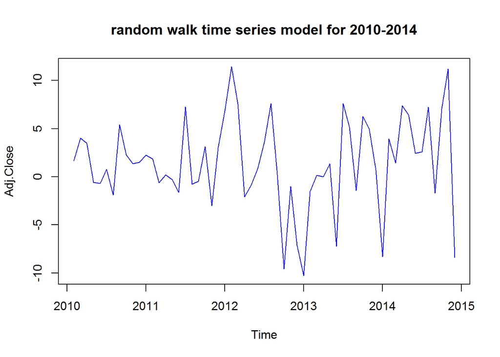

```r
AAPL_monthly_last_five_data.ts.diff <- diff(AAPL_monthly_last_five_data.ts, lag=1)
plot(AAPL_monthly_last_five_data.ts.diff, ylab='Adj.Close',main="random walk time series model for 2010-2014", col="blue")
```

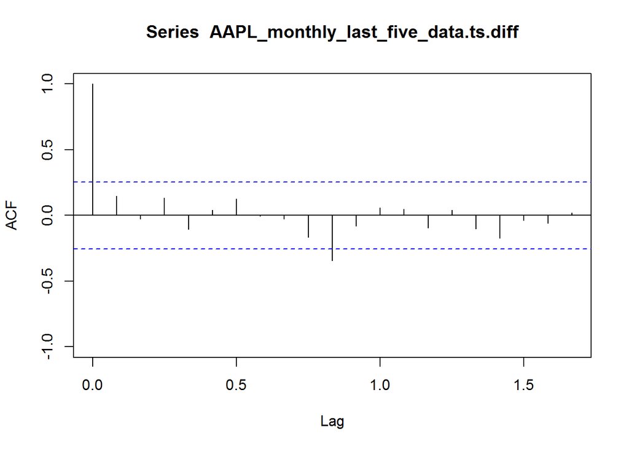

```r
acf(AAPL_monthly_last_five_data.ts.diff, na.action=na.pass, ylim=c(-1,1), lag.max = 20)
```

From the correlogram plot, we can see it is better than the previous decomposition model (as there are less significant points). However, it is still not very good. The reason is that it doesn’t follow a strict random walk as there is also an increase trend.

Instead of just a random walk model, it should be a random walk with some drift. The random walk model can be adapted to allow for this by including a *drift* parameter $\sigma$.

$x[t]=x[t-1] + \sigma + w[t]$

We can explore the drift effect as below:

```r
mean(AAPL_monthly_last_five_data.ts.diff)
```

```
## [1] 1.406503
```

```r
mean(AAPL_monthly_last_five_data.ts.diff) + c(-2,2)*sd(AAPL_monthly_last_five_data.ts.diff)/sqrt(length(AAPL_monthly_last_five_data.ts.diff))
```

```
## [1] 0.1652882 2.6477184
```

Since the confidence interval does not include zero, we have evidence of positive drift over this period.

### **Auto-Regressive Model $AR(p)$**

The most natural formulation of a time series model is a linear regression approach on the past instances, i.e. a regression on the series itself. This coined the term autoregressive. In practice, such models prove to be very important; they are the most popular way of describing time series.

The series ${x[t]}$ is an autoregressive process of order $p$, abbreviated to $AR(p)$, if

$x[t] = \alpha1.x[t-1] + \alpha2.x[t-2] + . . . + \alpha p.x[t-p] + w[t]$

where ${w[t]}$ is white noise and the $\alpha i$ are the model parameters with $\alpha p != 0$ for an order $p$ process.

A very important point is $AR( p)$ models must only be fitted to stationary time series. Any potential trends and/or seasonal effects need to be removed first.

Fitting an $AR( p)$ model to data involves three main steps. First, the model and its order need to be identified. Second, the model parameters need to be estimated and third, the quality of the fitted model needs to be verified by residual analysis.

The model identification step first requires verifying that the data show properties which make it plausible that they were generated from an $AR( p)$ process. In particular, the time series we are aiming to model needs to be stationary, show an ACF with approximately exponentially decaying envelope and a PACF with a recognizable cut-off at some lag p smaller than about 5-10. (Note thattThe partial autocorrelation $pacf()$ at lag k is the correlation that results after removing the effect of any correlations due to the terms at shorter lags. For example, the partial autocorrelation of an $AR(1)$ process will be zero for all lags greater than 1.)

The choice of the model order p then relies on the analysis of the sample PACF. Following the paradigm of parameter parsimony, we would first try the simplest model that seems plausible. This means choosing the smallest p at which we suspect a cut-off, i.e. the smallest after which none, or only few and weakly significant partial autocorrelations follow.

Let us do the $acf()$ and $pacf()$ plot for our data.

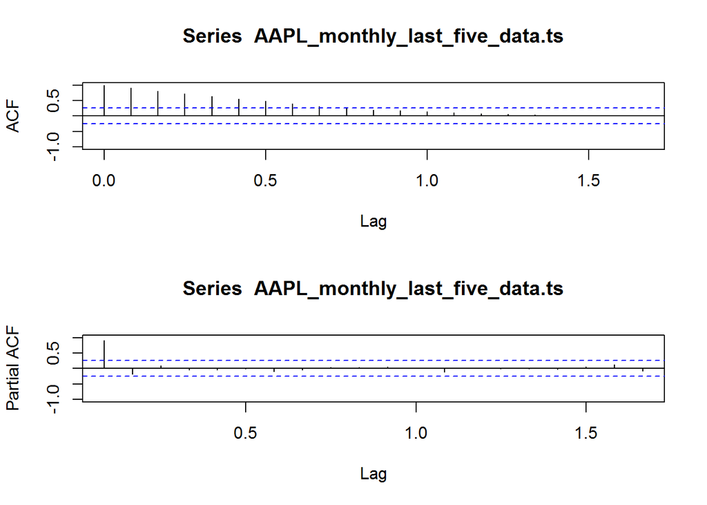

```r
par(mfrow=c(2,1))
acf(AAPL_monthly_last_five_data.ts, na.action=na.pass, ylim=c(-1,1),lag.max = 20)
pacf(AAPL_monthly_last_five_data.ts, na.action=na.pass, ylim=c(-1,1),lag.max = 20)
```

```r
par(mfrow=c(1,1))
```

Form the $pacf()$ plot, we should try with the smallest candidate first, which is $p=1$. Also we can try some higher order, like $p=12$. We need to note that lower order is better for modeling and prediction as the more parameters the greater noise that can be introduced into the model and hence standard deviation.

For the Parameter Estimation, we can try two different Auto-Regressive methods: $ar.ols()$ and $ar.burg()$

```r
# ar.ols() method for AR(1)
AAPL_monthly_last_five_data.ts.ar.ols <- ar.ols(AAPL_monthly_last_five_data.ts, aic=F, intercept=F, order=1)
AAPL_monthly_last_five_data.ts.ar.ols
```

```
##
## Call:
## ar.ols(x = AAPL_monthly_last_five_data.ts, aic = F, order.max = 1,     intercept = F)
##
## Coefficients:
##      1
## 0.9841
##
## Order selected 1  sigma^2 estimated as  24.2
```

```r
AAPL_monthly_last_five_data.ts.ar.ols$x.mean
```

```
## [1] 63.50317
```

```r
# ar.burg() method for AR(12)
AAPL_monthly_last_five_data.ts.ar.burg <- ar.burg(AAPL_monthly_last_five_data.ts, aic=F, intercept=F, order.max=12)
AAPL_monthly_last_five_data.ts.ar.burg
```

```
##
## Call:
## ar.burg.default(x = AAPL_monthly_last_five_data.ts, aic = F,     order.max = 12, intercept = F)
##
## Coefficients:
##       1        2        3        4        5        6        7        8
##  1.2121  -0.3093   0.3116  -0.3545   0.2329  -0.0226  -0.0195  -0.0971
##       9       10       11       12
## -0.0890  -0.1764   0.3522  -0.0718
##
## Order selected 12  sigma^2 estimated as  18.8
```

```r
AAPL_monthly_last_five_data.ts.ar.burg$x.mean
```

```
## [1] 63.50317
```

While we still recommend investigating on the suitable order by analyzing ACF and PACF, It is still recommended to use AIC as a second opinion. We will discuss it more in ARIMA modeling.

When comparing different models, a simple approach is to plot the original series along with the fitted model values. A good model yields residuals that resemble a White Noise process.

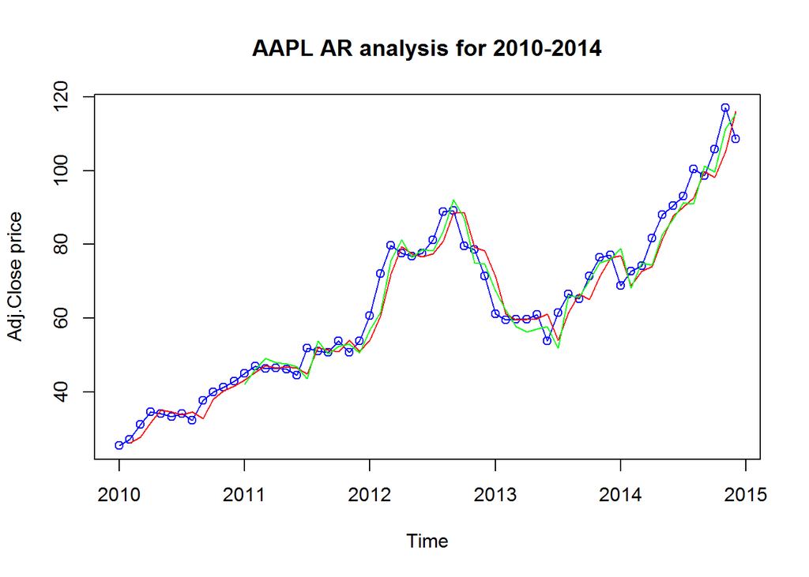

```r
plot(AAPL_monthly_last_five_data.ts, main ='AAPL AR analysis for 2010-2014', xlab="Time", ylab="Adj.Close price", type="o", col="blue")
lines(AAPL_monthly_last_five_data.ts - AAPL_monthly_last_five_data.ts.ar.ols$resid, col="red")
lines(AAPL_monthly_last_five_data.ts - AAPL_monthly_last_five_data.ts.ar.burg$resid, col="green")
```

While some differences are visible, it is not easy to judge from the fitted values which of the two models is preferable. So let us do the ACF/PACF correlogram plots to explore the quality of model.

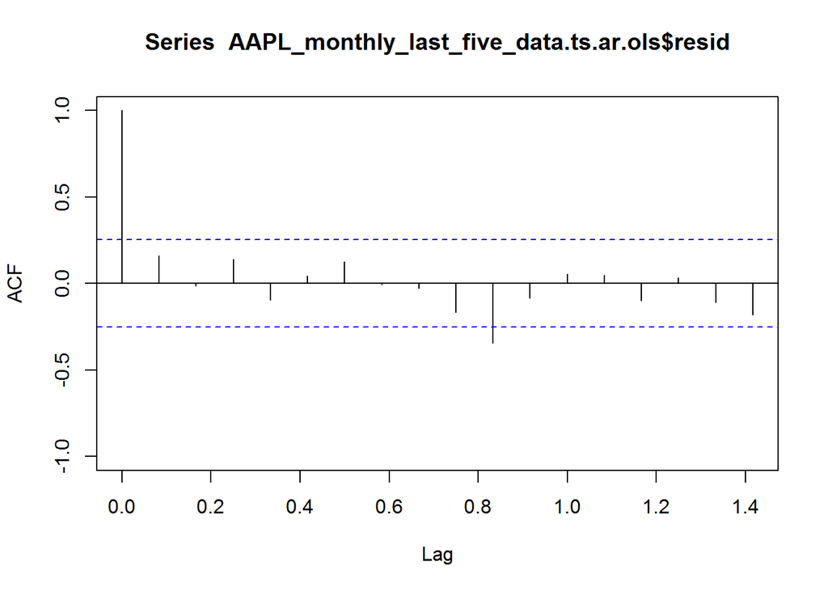

```r
#par(mfrow=c(2,1))
acf(AAPL_monthly_last_five_data.ts.ar.ols$resid, na.action=na.pass, ylim=c(-1,1))
```

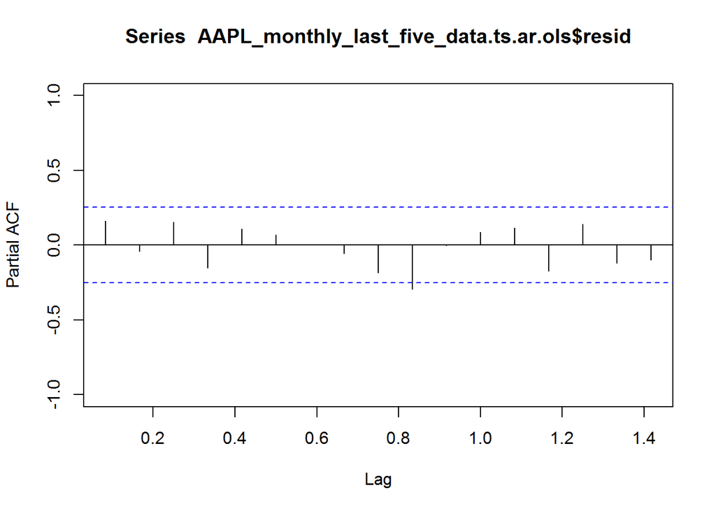

```r
pacf(AAPL_monthly_last_five_data.ts.ar.ols$resid, na.action=na.pass, ylim=c(-1,1))
```

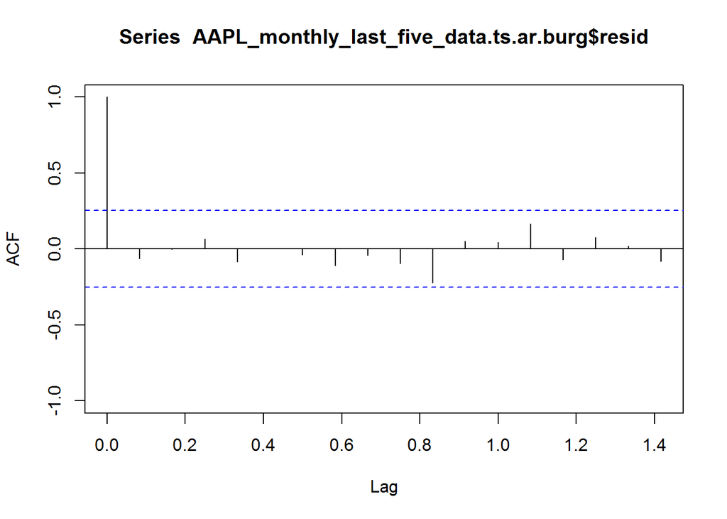

```r
#par(mfrow=c(1,1))
#par(mfrow=c(2,1))
acf(AAPL_monthly_last_five_data.ts.ar.burg$resid, na.action=na.pass, ylim=c(-1,1))
```

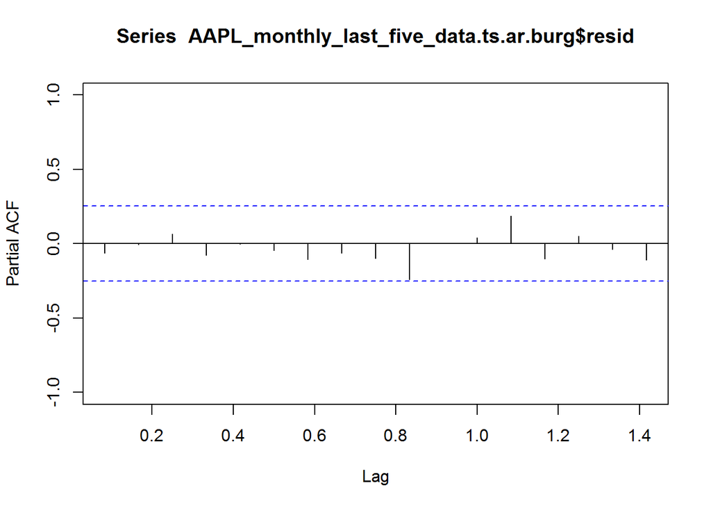

```r
pacf(AAPL_monthly_last_five_data.ts.ar.burg$resid, na.action=na.pass, ylim=c(-1,1))
```

```r
#par(mfrow=c(1,1))
```

From the ACF/PACF plots, we can see that the $AP(12)$ is better for modeling as it doesn’t show any significant autocorrection point. Also it is always worthwhile to generate a Normal QQ-Plot for verifying this:

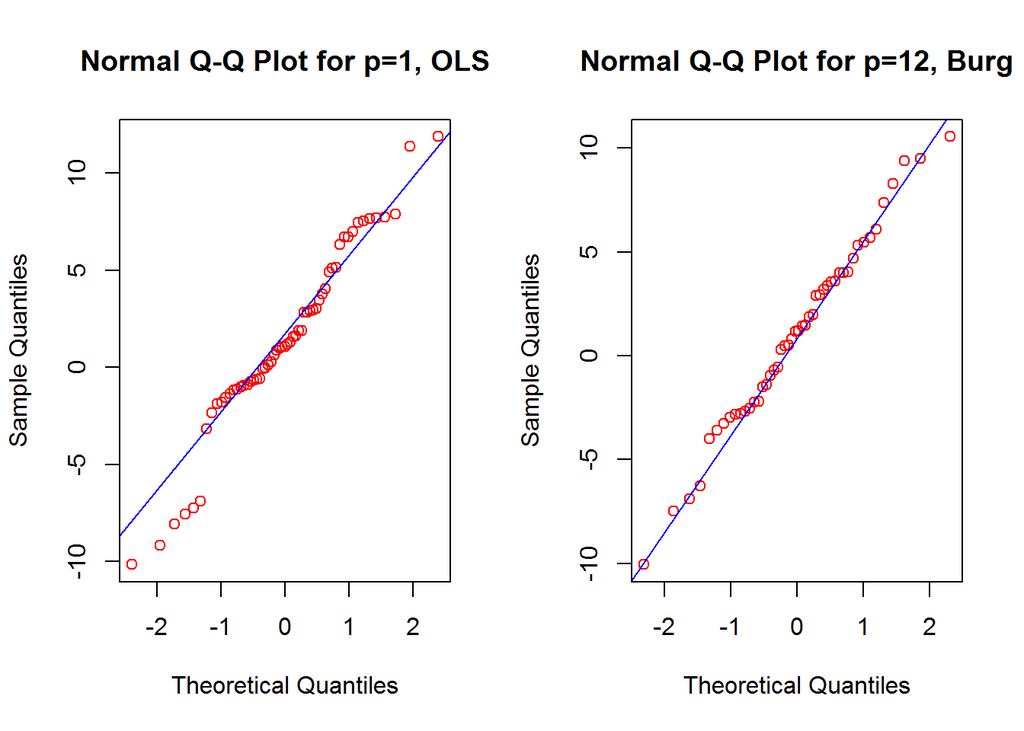

```r
par(mfrow=c(1,2))
qqnorm(as.numeric(AAPL_monthly_last_five_data.ts.ar.ols$resid),main = "Normal Q-Q Plot for p=1, OLS",col='red')
qqline(as.numeric(AAPL_monthly_last_five_data.ts.ar.ols$resid),col="blue")
qqnorm(as.numeric(AAPL_monthly_last_five_data.ts.ar.burg$resid), main = "Normal Q-Q Plot for p=12, Burg", col="red")
qqline(as.numeric(AAPL_monthly_last_five_data.ts.ar.burg$resid),col="blue")
```

```r
par(mfrow=c(1,1))
```

It is easy to see that the Normal QQ-Plot also shows the $AP(12)$ model is better. However, we still need to note that the higher order is not good for prediction as it considers too much parameters (kind like the “overfitting” problem in machine learning).

### **Moving average models $MA(q)$**

Before we introduce the ARIMA model, it would be better to introduce the moving average model $MA(q)$.

A time series model ${x[t]}$ is strictly stationary if the joint statistical distribution of $x[t1] , . . . , x[tn]$ is the same as the joint distribution of $x[t1+m], . . . , x[tn+m]$ for all $t1, . . . , tn$ and $m$, so that the distribution is unchanged after an arbitrary time shift. If a series is not strictly stationary but the mean and variance are constant in time and the autocovariance only depends on the lag, then the series is called second-order stationary.

A moving average (MA) process of order $q$ is a linear combination of the current white noise term and the $q$ most recent past white noise terms and is defined by

$x[t] = w[t] + \beta 1.w[t-1] + . . . + \beta q.w[t-q]$

where ${w[t]}$ is white noise with zero mean and variance $\sigma^2[w]$.

An $MA(q)$ model can be fitted to data in R using the arima function with the order function parameter set to $c(0,0,q)$. Below is the example application of $MA(1)$ on our data.

```r
AAPL_monthly_last_five_data.ts.lm.ma <- arima(AAPL_monthly_last_five_data.ts.lm$residuals, order=c(0,0,1), method = "CSS") # Use the CSS approach for the parameter estimation
AAPL_monthly_last_five_data.ts.lm.ma
```

```
##
## Call:
## arima(x = AAPL_monthly_last_five_data.ts.lm$residuals, order = c(0, 0, 1), method = "CSS")
##
## Coefficients:
##          ma1  intercept
##       0.9439     0.0669
## s.e.  0.0857     1.5937
##
## sigma^2 estimated as 39.89:  part log likelihood = -195.72
```

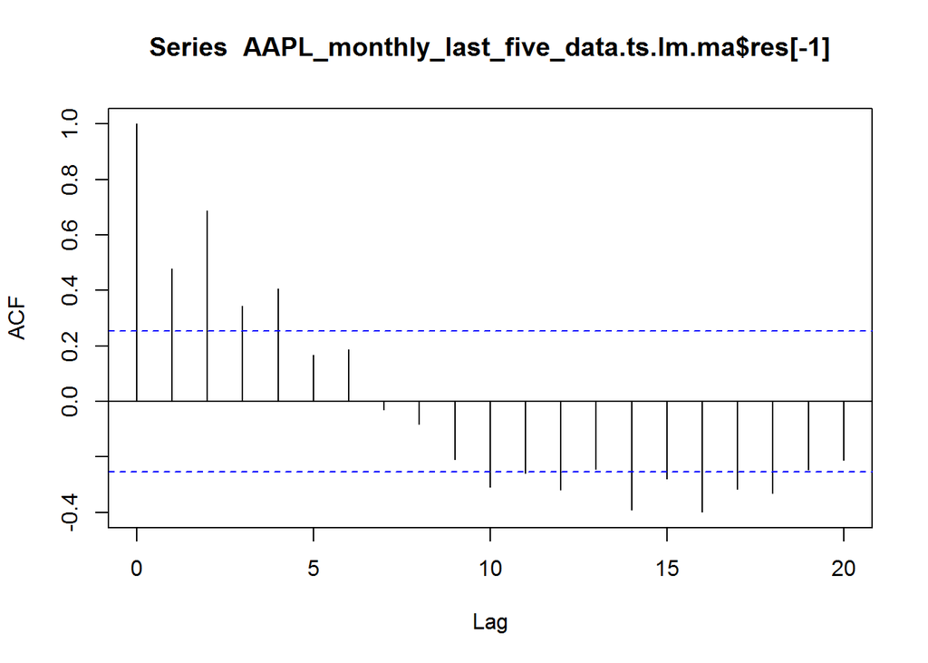

```r
acf(AAPL_monthly_last_five_data.ts.lm.ma$res[-1], lag.max = 20)
```

From the result we can see sigma^2 estimated as 39.89, which is very big and the acf() is also not good, the model is bad, as the model is not stationary

### **ARIMA(p,d,q) Model**

Knowing the $AR(p)$ model and $MA(q)$ model, we can easily understand the $ARMA(p,q)$ model.

A time series ${x[t]}$ follows an autoregressive moving average (ARMA) process of order $(p,q)$, denoted $ARMA(p,q)$, when

$x[t] = \alpha 1. x[t-1] + \alpha 2.x[t-2] + ... + \alpha p.x[t-p] + \beta 1. w[t-1] + \beta 2. w[t-2] + ... + \beta q. w[t-q]$

where ${w[t]}$ is white noise. Note that $AP(p)$ is $ARMA(p,0)$. Often, an $ARMA( p,q)$ requires (far) fewer parameters than pure AR or MA processes would.

Clearly, A time series ${x[t]}$ follows an $ARIMA(p, d, q)$ process if the dth differences of the ${x[t]} series are an $ARMA(p, q)$ process.

In fitting ARIMA model, the idea of parsimony is important in which the model should have as small parameters as possible yet still be capable of explaining the series (p and q should be 2 or less, or the total number of parameters should be less than 3 in view of Box-Jenkins method4). The more parameters the greater noise that can be introduced into the model and hence standard deviation

We can use the AIC result to determine the appropriate ARIMA model (usually choose the smallest AIC model)

Below is the code of several different arima() model functions for fitting the data and calculate the AIC result.

```r
arima010 <- arima(AAPL_monthly_last_five_data.ts, order = c(0,1,0))
AIC(arima010)
```

```
## [1] 357.7145
```

```r
arima110 <- arima(AAPL_monthly_last_five_data.ts, order = c(1,1,0))
AIC(arima110)
```

```
## [1] 356.5794
```

```r
arima011 <- arima(AAPL_monthly_last_five_data.ts, order = c(0,1,1))
AIC(arima011)
```

```
## [1] 356.2322
```

```r
arima111 <- arima(AAPL_monthly_last_five_data.ts, order = c(1,1,1))
AIC(arima111)
```

```
## [1] 356.2006
```

```r
arima012 <- arima(AAPL_monthly_last_five_data.ts, order = c(0,1,2))
AIC(arima012)
```

```
## [1] 357.6883
```

```r
arima112 <- arima(AAPL_monthly_last_five_data.ts, order = c(1,1,2))
AIC(arima112)
```

```
## [1] 357.4676
```

```r
arima210 <- arima(AAPL_monthly_last_five_data.ts, order = c(2,1,0))
AIC(arima210)
```

```
## [1] 358.5611
```

```r
arima211 <- arima(AAPL_monthly_last_five_data.ts, order = c(2,1,1))
AIC(arima211)
```

```
## [1] 357.3354
```

```r
arima212 <- arima(AAPL_monthly_last_five_data.ts, order = c(2,1,2))
AIC(arima212)
```

```
## [1] 358.4608
```

From the AIC result, we can see the smallest AIC is 356.2, which is for model $ARIMA(1,1,1)$. For the choose of the most appropriate ARIMA model, in the prediction section we also show a loop function, which is more powerful.

We can also see the quality of this model by acf() plot.

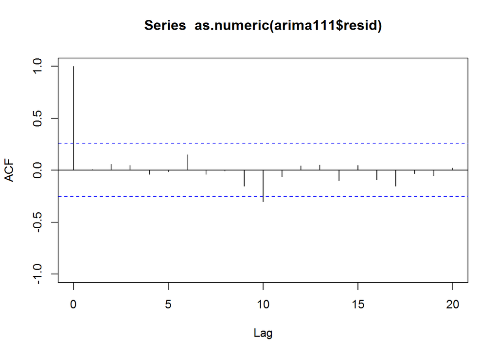

```r
acf(as.numeric(arima111$resid), na.action=na.pass, ylim=c(-1,1), lag.max = 20)
```

From the acf() result, we can see there is still some autocorrection point, which means the model is still not very good.

We can also perform the log transformation to get better result.

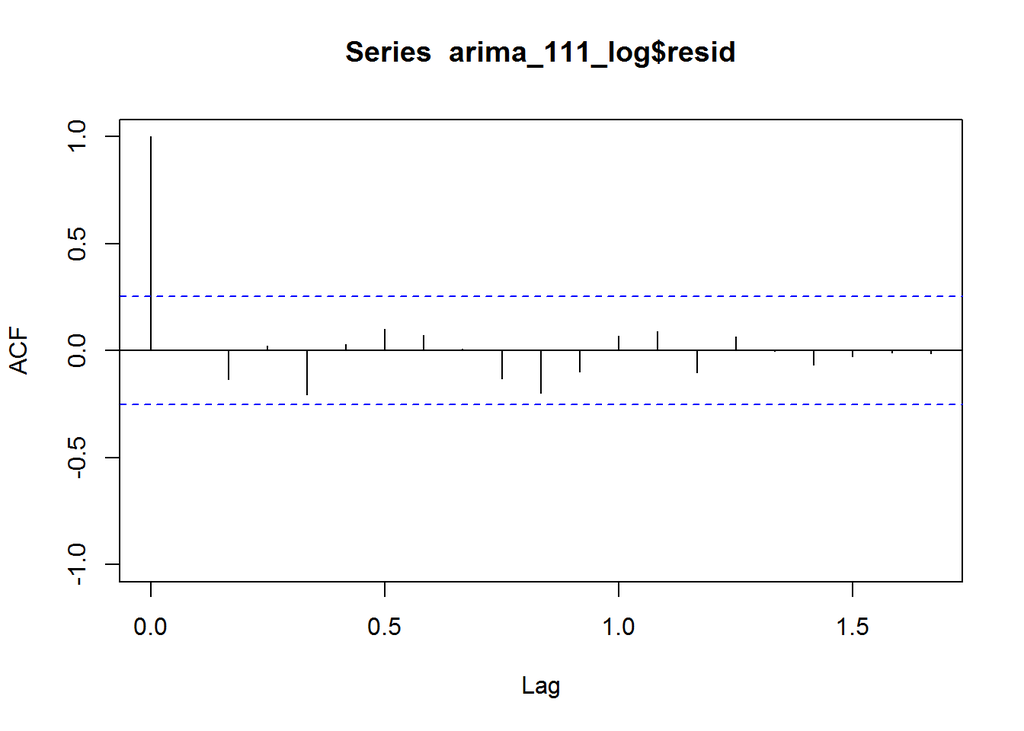

```r
arima_111_log <- arima(log(AAPL_monthly_last_five_data.ts), order=c(1,1,1))
acf(arima_111_log$resid, na.action=na.pass, ylim=c(-1,1), lag.max = 20)
```